# AYTS - FINAL ASSIGNMENT

## Kyle Richardson - A00047263

In this project I will be analzying a dataset of Dungeons and Dragons character sheets from DndBeyond, the offical online interface for the game. Dungeons and Dragons(D&D) is a popular tabletop roleplaying game that boasts millions of players globaly. I found this dataset on [kaggle](https://www.kaggle.com/datasets/maximebonnin/dnd-characters-test)

In D&D, each player has a character sheet which tracks the mechanics and logistics of their character. This sheet is either kept in paper or stored on digital services like DndBeyond. The dataset I'm working with here is from their website and contains over 1.2 million unique character sheets. Analysing this data is incredibly useful for discovering trends between players, and uncovering what are the most popular aspects of the game and other details that could drive marketing or product development.

My research question is: Every playgroup plays D&D in their own unique way. By analyzing the types of characters players'create, can we identify popular styles of play that could be catered to with future D&D products.

First, let's have a look at the dataset.

```python
import pandas as pd
import numpy as np
import matplotlib.pyplot as plt
import seaborn as sns

df = pd.read_csv("over_one_mil_chars.csv")
print(df.shape)
print(df.info())
print(df.describe())
print(df.sample(5))
```

```
(1204252, 23)
<class 'pandas.core.frame.DataFrame'>
RangeIndex: 1204252 entries, 0 to 1204251
Data columns (total 23 columns):
 #   Column                Non-Null Count    Dtype
---  ------                --------------    -----
 0   Unnamed: 0            1204252 non-null  int64
 1   char_id               1204252 non-null  int64
 2   name                  1199602 non-null  object
 3   base_hp               1204252 non-null  int64
 4   stats_1               1204252 non-null  int64
 5   stats_2               1204252 non-null  int64
 6   stats_3               1204252 non-null  int64
 7   stats_4               1204252 non-null  int64
 8   stats_5               1204252 non-null  int64
 9   stats_6               1204252 non-null  int64
 10  background            898870 non-null   object
 11  race                  1204252 non-null  object
 12  class_starting        1204252 non-null  object
 13  class_starting_level  1204252 non-null  int64
 14  subclass_starting     607804 non-null   object
 15  class_other           78814 non-null    object
 16  subclass_other        48834 non-null    object
 17  total_level           1204252 non-null  int64
 18  feats                 219008 non-null   object
 19  inventory             832291 non-null   object
 20  date_modified         1204252 non-null  object
 21  notes_len             1204252 non-null  int64
 22  gold                  1204252 non-null  float64
dtypes: float64(1), int64(12), object(10)
memory usage: 211.3+ MB
None
         Unnamed: 0       char_id       base_hp       stats_1       stats_2  \
count  1.204252e+06  1.204252e+06  1.204252e+06  1.204252e+06  1.204252e+06
mean   6.021255e+05  8.760689e+05  2.347389e+01  1.051853e+01  1.153501e+01
std    3.476378e+05  4.414356e+05  2.677593e+01  4.829688e+00  4.918547e+00
min    0.000000e+00  1.000000e+00 -6.240000e+02  0.000000e+00  0.000000e+00
25%    3.010628e+05  5.446485e+05  8.000000e+00  8.000000e+00  1.000000e+01
50%    6.021255e+05  8.185030e+05  1.200000e+01  1.100000e+01  1.300000e+01
75%    9.031882e+05  1.188040e+06  2.900000e+01  1.400000e+01  1.500000e+01
```

[output cut: 42 more lines]

```
                                                 inventory  \
1195179                                                NaN
184446   Breastplate/Javelin/Light Hammer/Greatsword/Ba...
433154   Shield/Chain Mail/Dagger/Longsword/Explorer's ...
467506   Shield/Breastplate/Dagger/Bedroll/Waterskin/Pr...
819996   Dagger/Dagger/Quarterstaff/Clothes, Fine/Signe...

                    date_modified notes_len   gold
1195179      2018-06-29T15:37:47Z         0    0.0
184446       2018-06-29T15:37:47Z        38   10.0
433154   2020-10-25T02:28:13.123Z         0    0.0
467506       2018-06-29T15:37:47Z        88   10.0
819996    2019-02-25T15:45:57.53Z        24  118.2

[5 rows x 23 columns]
```

This dataset is huge, so I will begin by dropping columns that I won't use for this analysis.

```python
df = df.drop('date_modified', axis=1)
df = df.drop('notes_len', axis = 1)
df = df.drop("gold", axis = 1)
df = df.drop("char_id", axis = 1)
```

After looking at the description on Kaggle, I found that stats_1 through stats_6 represent the 6 character attributes in the game: strength, dexterity, constitution, intelligence, wisdom, and charisma. I will capitalise and rename these columns for improved readability.

```python
df.rename(columns={"base_hp": "Hp",'stats_1':'Strength','stats_2': 'dexterity',"stats_3" :"constitution",
                  "stats_4" :"intelligence", "stats_5" :"wisdom", "stats_6" :"charisma"}, inplace=True)
df = df.rename(columns={"Unnamed: 0": "Id"})
df.columns = df.columns.str.strip().str.title()
df.sample(5)
```

|  | Id | Name | Hp | Strength | Dexterity | Constitution | Intelligence | Wisdom | Charisma | Background | Race | Class_Starting | Class_Starting_Level | Subclass_Starting | Class_Other | Subclass_Other | Total_Level | Feats | Inventory |
| --- | --- | --- | --- | --- | --- | --- | --- | --- | --- | --- | --- | --- | --- | --- | --- | --- | --- | --- | --- |
| 400429 | 400429 | Draco Drakerider | 1 | 13 | 8 | 12 | 15 | 14 | 10 | NaN | Dragonborn | Druid | 4 | NaN | NaN | NaN | 4 | NaN | Book/Case, Map or Scroll/Explorer's Pack/Carto... |
| 560526 | 560526 | Iskaral | 8 | 0 | 0 | 0 | 0 | 0 | 0 | Hermit | Tabaxi | Warlock | 1 | The Great Old One | NaN | NaN | 1 | NaN | NaN |
| 1147560 | 1147560 | Umeyarus Ethanasath | 34 | 12 | 12 | 9 | 12 | 16 | 13 | Haunted One | Elf | Ranger | 5 | Hunter | NaN | NaN | 5 | NaN | NaN |
| 668210 | 668210 | Arsene | 8 | 12 | 13 | 14 | 13 | 13 | 13 | Criminal / Spy | Half-Elf | Rogue | 1 | NaN | NaN | NaN | 1 | NaN | Leather/Dagger/Dagger/Rapier/Shortsword/Backpa... |
| 1012591 | 1012591 | Lil | 10 | 15 | 12 | 15 | 13 | 14 | 16 | Soldier | Yuan-ti Pureblood | Blood Hunter (archived) | 1 | NaN | NaN | NaN | 1 | NaN | NaN |

Next, let's see if theres any null values in any of the columns

```python
df.isna().sum()
```

```
Id                            0
Name                       4650
Hp                            0
Strength                      0
Dexterity                     0
Constitution                  0
Intelligence                  0
Wisdom                        0
Charisma                      0
Background               305382
Race                          0
Class_Starting                0
Class_Starting_Level          0
Subclass_Starting        596448
Class_Other             1125438
Subclass_Other          1155418
Total_Level                   0
Feats                    985244
Inventory                371961
dtype: int64
```

From this look, we can quite alot of null values in "Class_Other" and "Subclass_Starting". I next want to see if i differentiate between rows where this value in purposefully left blank and where it is missing.

In D&D, when you create a character you must first pick a class, which you get 1 level in("Class_Starting"). As you progress in the game, you can increase the level of your class. Once a character reaches level 3 you must choose a subclass ("Subclass_starting") for your character. Therefore, you would expect null values in "Subclass_starting" where the character hasn't hit level 3 yet, and conversely, any character with "class_starting">3 and "subclass_starting" is null must be missing data. However in dnd you also have the ability to multiclass ("class_other") - meaning you can level up in a second class at every level up checkpoint. The same subclass rules apply, therefore if Total_Level >= 5 then there must be a value in "Subclass_Starting" OR "Subclass_Other". The below code is an attempt to discover cases where there is *true* missing data in these columns.

```python
df["Class_Starting_Level"] = pd.to_numeric(df["Class_Starting_Level"], errors="coerce")
df["Class_Other"] = pd.to_numeric(df["Class_Other"], errors="coerce")
df["Class_Other_Level"] = df["Total_Level"] - df["Class_Starting_Level"]

missing_starting_subclass = df[
    (df["Class_Starting_Level"] >= 3) &
    (df["Subclass_Starting"].isna())]

missing_other_subclass = df[
    (df["Class_Other_Level"] >= 3) &
    (df["Subclass_Other"].isna())]

missing_any_subclass = df[
    (df["Total_Level"] >= 5) &
    (df["Subclass_Starting"].isna()) &
    (df["Subclass_Other"].isna())
]

missing_subclass_data = df[
    ((df["Class_Starting_Level"] >= 3) & (df["Subclass_Starting"].isna())) |
    ((df["Class_Other_Level"] >= 3) & (df["Subclass_Other"].isna())) |
    ((df["Total_Level"] >= 5) & (df["Subclass_Starting"].isna()) & (df["Subclass_Other"].isna()))
]
print(f"Total characters that are missing subclass data: {len(missing_subclass_data)}")
print(f"Characters that multiclassed: {df["Class_Other"].notna().sum()}")
print(f"Characters that multiclassed & have a other subclass: {df["Subclass_Other"].notna().sum()}")
print(F"Characters that multiclassed & don't have a other subclass:{len(missing_subclass_data) - df["Subclass_Other"].notna().sum()}")
```

```
Total characters that are missing subclass data: 94676
Characters that multiclassed: 0
Characters that multiclassed & have a other subclass: 48834
Characters that multiclassed & don't have a other subclass:45842
```

There a good deal of NaN values in this dataset, alot of which as similar to the subclass situtation where a character hasn't progressed enough to get data in that column, as opposed to it being missing data. Considering this, I am going to leave the remaining null values as null as it takes up less memory & is more efficient to run code over.

```python
df = df.drop("Class_Other", axis=1)
new_order = ["Id", "Name","Race", "Hp","Strength","Dexterity","Constitution","Intelligence",
             "Wisdom","Charisma", "Total_Level","Class_Starting","Class_Starting_Level",
             "Subclass_Starting","Class_Other_Level","Subclass_Other","Background","Feats",
             "Inventory"]
df=df[new_order] # reordering the columns for readability
df.sample(5)
```

|  | Id | Name | Race | Hp | Strength | Dexterity | Constitution | Intelligence | Wisdom | Charisma | Total_Level | Class_Starting | Class_Starting_Level | Subclass_Starting | Class_Other_Level | Subclass_Other | Background | Feats | Inventory |
| --- | --- | --- | --- | --- | --- | --- | --- | --- | --- | --- | --- | --- | --- | --- | --- | --- | --- | --- | --- |
| 1078574 | 1078574 | Tanathalan Aldaren (Tan) | Half-Elf | 22 | 12 | 15 | 13 | 8 | 10 | 14 | 3 | Ranger | 3 | Hunter | 0 | NaN | Folk Hero | NaN | Studded Leather/Shortsword/Shortsword/Longbow/... |
| 123940 | 123940 | "Rumpbutter" | Gnome | 28 | 12 | 18 | 12 | 18 | 13 | 15 | 5 | Rogue | 5 | Arcane Trickster | 0 | NaN | Charlatan | NaN | Cloak of Elvenkind/Arrows, +1/Shortsword of Wa... |
| 107845 | 107845 | Viktor | Goliath | 12 | 14 | 15 | 13 | 8 | 12 | 10 | 1 | Barbarian | 1 | NaN | 0 | NaN | Haunted One | NaN | Dagger of Venom/Leather/Dagger/Dagger/Shortbow... |
| 950875 | 950875 | Egg | Half-Elf | 8 | 12 | 15 | 13 | 8 | 14 | 10 | 1 | Rogue | 1 | NaN | 0 | NaN | Soldier | NaN | Leather/Shortsword/Shortsword/Longbow/Arrows/B... |
| 948101 | 948101 | Vita Medicus | Aasimar | 8 | 13 | 8 | 14 | 15 | 12 | 10 | 1 | Cleric | 1 | Life Domain | 0 | NaN | Noble | NaN | Shield/Chain Mail/Light Hammer/Mace/Backpack/B... |

Next, let's have a look at the most popular classes in our dataset.

```python
class_counts = df["Class_Starting"].value_counts()
class_counts
```

```
Class_Starting
Fighter                    141664
Rogue                      137773
Ranger                     108182
Paladin                     99910
Wizard                      98154
Cleric                      97858
Barbarian                   95489
Bard                        86859
Warlock                     86515
Sorcerer                    81233
Monk                        79001
Druid                       76494
Blood Hunter (archived)     14179
Artificer                     435
Blood Hunter                  403
Artificer (UA)                103
Name: count, dtype: int64
```

since there's hardly any data for "Blood Hunter", I'm just going to combine it with "Blood Hunter (arc)" under the simplier label "Blood Hunter". I will do the same for "Artificer".

```python
df['Class_Starting'] = df['Class_Starting'].replace('Blood Hunter (archived)', 'Blood Hunter')
df["Class_Starting"] = df["Class_Starting"].replace("Artificer (UA)", "Artificer")

print((df["Class_Starting"] == "Blood Hunter (archived)").sum())
print((df["Class_Starting"] == "Blood Hunter").sum())
print((df["Class_Starting"] == "Artificer (UA)").sum())
```

```
0
14582
0
```

Now that I have fully cleaned the data, I can start making visual diagrams for analysis. First let's start with a look at D&D's classes ranked by popularity.

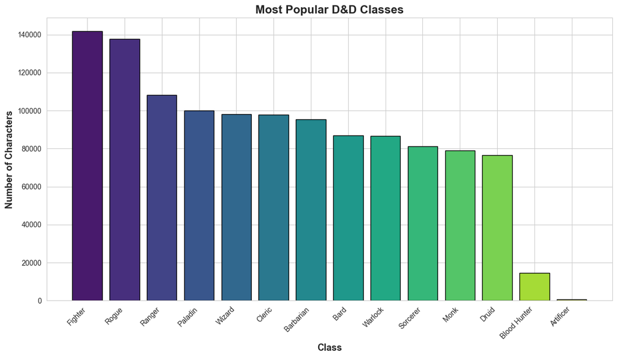

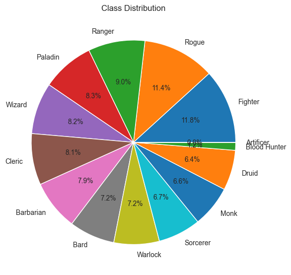

```python
class_counts = df['Class_Starting'].value_counts()

sns.set_style("whitegrid")
plt.figure(figsize=(12, 7))
plt.bar(range(len(class_counts)), class_counts.values, color=sns.color_palette("viridis", len(class_counts)),
    edgecolor="black")

plt.xlabel('Class', fontsize=13, fontweight='bold')
plt.ylabel('Number of Characters', fontsize=13, fontweight='bold')
plt.title('Most Popular D&D Classes', fontsize=16, fontweight='bold')
plt.xticks(range(len(class_counts)), class_counts.index, rotation=45, ha='right')
plt.tight_layout()
plt.show()

class_counts.plot(kind='pie', autopct='%1.1f%%', figsize=(6,6))
plt.title('Class Distribution')
plt.ylabel('')
plt.tight_layout()
plt.show()
```

The bar chart shows that "Fighter" and "Rogue" are ahead of the other classes, and that "Blood Hunter" and "Artificer" the least popular classes by a wide margin. With this knowledge, I want to see if I can determine more about these Classes, and how players play the game, by looking at their stat distribution.

First I'll get another look at the mean, median, min, and max values for character stats

```python
stats = ['Strength', 'Dexterity', 'Constitution', 'Intelligence', 'Wisdom', 'Charisma']
df_stats = df[stats].agg(['mean', 'median', 'min', 'max']).round(2)
print(df_stats)
print("-------------------------")
print("Correlation between Stats")
print(df[stats].corr().round(3))
```

```
        Strength  Dexterity  Constitution  Intelligence  Wisdom  Charisma
mean       10.52      11.54         11.47         10.26   10.91     10.67
median     11.00      13.00         13.00         11.00   12.00     12.00
min         0.00       0.00          0.00          0.00    0.00      0.00
max        30.00      30.00         30.00         30.00   30.00     30.00
-------------------------
Correlation between Stats
              Strength  Dexterity  Constitution  Intelligence  Wisdom  \
Strength         1.000      0.689         0.794         0.603   0.673
Dexterity        0.689      1.000         0.809         0.753   0.762
Constitution     0.794      0.809         1.000         0.746   0.793
Intelligence     0.603      0.753         0.746         1.000   0.761
Wisdom           0.673      0.762         0.793         0.761   1.000
Charisma         0.613      0.712         0.745         0.731   0.695

              Charisma
Strength         0.613
Dexterity        0.712
Constitution     0.745
Intelligence     0.731
Wisdom           0.695
Charisma         1.000
```

From this cursory glance, there seems to be actionable correlation between stats. I'll represent the data in a chart to get a better idea of it.

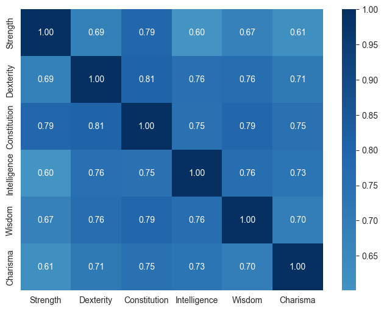

| Class_Starting | Strength | Dexterity | Constitution | Intelligence | Wisdom | Charisma |
| --- | --- | --- | --- | --- | --- | --- |
| Artificer | 9.77 | 13.07 | 12.92 | 14.56 | 11.52 | 10.83 |
| Barbarian | 13.52 | 11.80 | 12.77 | 8.95 | 9.96 | 9.57 |
| Bard | 9.03 | 12.08 | 10.88 | 10.57 | 10.22 | 13.36 |
| Blood Hunter | 11.92 | 11.89 | 11.91 | 9.99 | 11.44 | 9.38 |
| Cleric | 10.37 | 9.16 | 11.06 | 9.45 | 12.45 | 9.65 |
| Druid | 9.38 | 11.10 | 11.62 | 10.73 | 13.10 | 9.79 |
| Fighter | 12.89 | 11.64 | 12.32 | 9.82 | 10.07 | 9.74 |
| Monk | 10.55 | 13.40 | 11.58 | 9.70 | 12.44 | 9.37 |
| Paladin | 13.10 | 9.91 | 12.01 | 9.30 | 10.44 | 12.32 |
| Ranger | 10.79 | 13.23 | 11.33 | 10.15 | 11.83 | 9.52 |
| Rogue | 9.71 | 13.41 | 10.94 | 10.93 | 10.61 | 11.15 |
| Sorcerer | 8.49 | 10.71 | 11.18 | 10.56 | 10.14 | 12.49 |
| Warlock | 8.00 | 9.95 | 10.37 | 9.72 | 9.57 | 11.79 |
| Wizard | 8.43 | 11.02 | 11.17 | 13.18 | 10.84 | 10.02 |

```python
df_sample = df.sample(50000, random_state=42)

corr = df_sample[stats].corr()
plt.figure(figsize=(8, 6))
sns.heatmap(corr, annot=True, cmap='RdBu', fmt=".2f", center=0)
plt.show()

class_stats_mean = df.groupby('Class_Starting')[stats].mean()
class_stats_mean.round(2)
```

The above table is particularly useful to seeing the average stats per class. I will reference this later when doing deeper analysis.

I noticed that the max value in all stats was 30. After doing some research, I discovered that D&D characters can only naturally increase each stat to 20 throughout the game; albeit on a rare occasion a stat could 21 or 22. I'll look at how many unnatural cases there are in my data.

```python
outlier_counts = (df[stats] >= 22).sum()
print(f"the total amount of characters with a single stat over 22 : {outlier_counts.sum()}")
print(outlier_counts)
```

```
the total amount of characters with a single stat over 22 : 134
Strength        34
Dexterity       24
Constitution    23
Intelligence    18
Wisdom          17
Charisma        18
dtype: int64
```

Ultimately, this count is insignificant in my huge dataset. However I am next going to analyse my data using violin plots and the wide range of 1-30 makes them difficult to read. For this reason, I will cap the below plots at 22 for improved visuals.

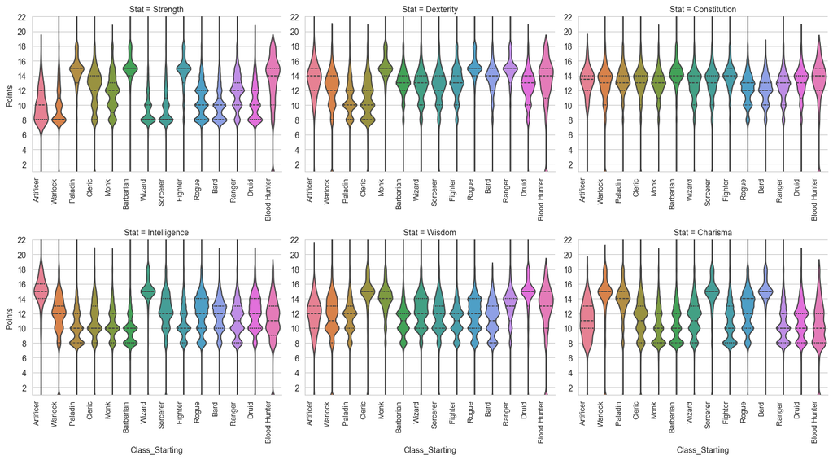

```python
# This takes a minute or two to run
df_melted = df.melt(id_vars=['Class_Starting'], value_vars=stats, #stats from above
                    var_name='Stat', value_name='Points')
class_order = df['Class_Starting'].unique().tolist()
num_classes = len(class_order)
custom_palette = sns.color_palette('husl',num_classes)

g = sns.catplot(data=df_melted, x='Class_Starting',y='Points',col='Stat',kind='violin',
                col_wrap=3, inner='quartile',height=4,aspect=1.2, order=class_order,
                sharex=False, sharey=False, hue='Class_Starting', palette=custom_palette)
g.set(ylim=(1, 22)) #points over 22 are unnatural.
for ax in g.axes.flatten():
    ax.set_yticks(range(2, 23, 2)) # points can only be round numbers, this changes y axis to go up in 2s.
g.set_xticklabels(rotation=90, ha='right', size=9)
g.tight_layout()
plt.show()
```

Looking at these graphs we can notice a few things. Considering that the mean "Strength" is 11, most of the points for the first and fourth most popular classes, "Fighter" and "Paladin", score between 13-16 strength, which is comparitively quite high . This is mirrored in "Dexterity" (mean of 11.5) for "Rogue" and "Ranger", the second and third most popular class.

From this insight it seems that a good chunk of the players enjoy the combat portion of D&D. With this knowledge, if I was a D&D writer or designer, I could publish more adventures and products that focus on combat. Conversely, there is room for improvement across the mental & social stats where I could perhaps write new classes, subclasses, or adventures which emphasis and promote these aspects of the game.

This analysis set out to explore whether meaningful differences in playstyles could be observed from the character sheets on DnDBeyond. By examining class distributions, character statistics, and other character-level attributes, several clear trends emerged which can be used in product development.